# HW#2_Data412_SydneyBall

Sydney Ball

2024-01-31

### Libraries

```r
library(tidyverse)
```

```r
library(ggplot2)
data("midwest")
```

## Question 1

Analyze the data set of “midwest”

```r
view(midwest)
help(midwest)
dim(midwest)[1] # ncolumns
```

```
## [1] 437
```

```r
dim(midwest)[2] #nrows
```

```
## [1] 28
```

There are 437 rows and 28 columns in the midwest data set. This means that there are 28 variables in the data. Three categorical in the data are state, inmetro, and county. The variable percollege is the percent of people who are college educated.

## Question 2

Histogram for poptotal

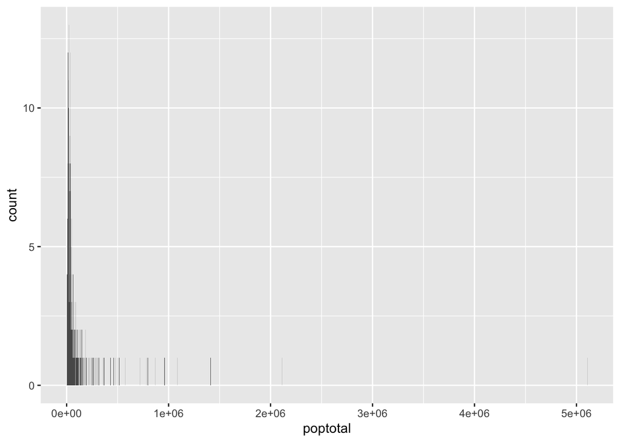

```r
ggplot(data = midwest) +
  geom_histogram(mapping= aes(x=poptotal), binwidth = 1000)
```

## Question 3

Produce a boxplot for area. Then find Q1, Q2, and Q3.

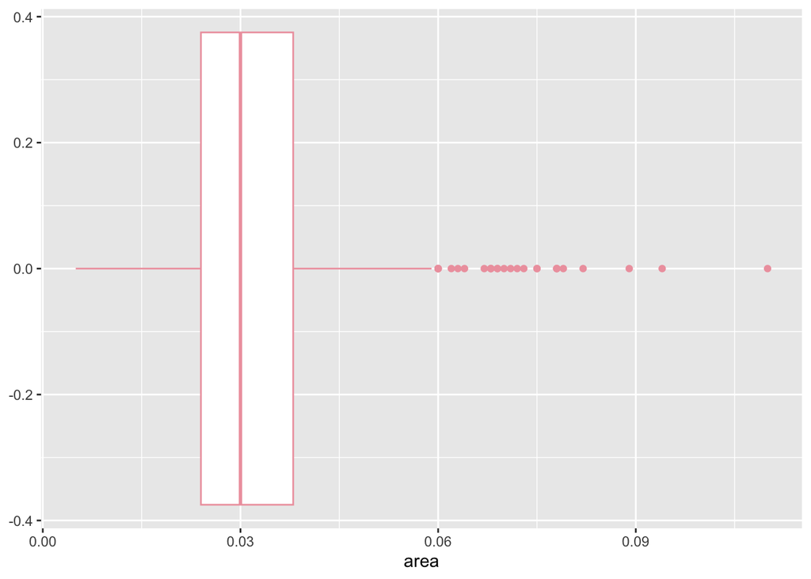

```r
ggplot(data = midwest) +
  geom_boxplot(mapping = aes(y=area), color = "lightpink2") +
  coord_flip()
```

```r
summary(midwest$area)
```

```
##    Min. 1st Qu.  Median    Mean 3rd Qu.    Max.
## 0.00500 0.02400 0.03000 0.03317 0.03800 0.11000
```